# Responses to Week Four Assignment

ID Last, First

2024-01-24

## Week Four Assignment

Choose at least two *similar* WDI codes with the *same scale*, and analyze the data.

- Create an R Notebook of a data analysis containing the following and submit the rendered file (e.g., `w4_g123456.nb.html`) in Moodle.
  1. Create an R Notebook using the R Notebook Template in Moodle and save it as `w4_g123456.Rmd`.
  2. Edit author with name, ID, and title.
- Contents should include the following:
  - A short abstract
  - Information of data including data name, data code (or id), description
  - Data including at least two indicators and a long table created using `pivot_longer`
  - A line graph using the long table with a color aesthetic to depict at least two indicators in a chart.
  - Several charts: a bar graph or a column graph, a histogram, a line graph, a scatter plot
  - Observations or questions for visualizations
- Include a choropleth map, if possible. (a challenge, not required)
- Run each code block and preview to create `w4_g123456.nb.html`.
  - Or, Run All under Run and Preview to check in your web browser!
  - You can also view your file (e.g. `w4_g123456.nb.html`) by opening it from your web browser.

Submit your R Notebook file (w4_g123456.nb.html) in Moodle (Week Four Assignment).

*Due Sunday 21, January 2024, 11:59 PM*

# Your Project

## Title of your project

*The title can be in the title in YAML.*

### About Data

#### List of Indicators Chosen:

1. Government expenditure on education, total (% of GDP): SE.XPD.TOTL.GD.ZS [[Link](https://data.worldbank.org/indicator/SE.XPD.TOTL.GD.ZS)], Labor force participation rate for ages 15-24, male (%) (modeled ILO estimate):SL.TLF.ACTI.1524.MA.ZS [[Link](https://data.worldbank.org/indicator/SL.TLF.ACTI.1524.MA.ZS)]Labor force participation rate for ages 15-24, female (%) (modeled ILO estimate) :SL.TLF.ACTI.1524.FE.ZS [[Link](https://data.worldbank.org/indicator/SL.TLF.ACTI.1524.FE.ZS)]
2. Urban population (% of total population) :SP.URB.TOTL.IN.ZS, Population living in slums (% of urban population) : EN.POP.SLUM.UR.ZS
3. Literacy rate, adult female (% of females ages 15 and above): SE.ADT.LITR.FE.ZS, Literacy rate, adult male (% of males ages 15 and above): SE.ADT.LITR.MA.ZS, GDP per capita, PPP (constant 2017 international $): NY.GDP.PCAP.PP.KD
4. Access to electricity, urban (% of urban population): EG.ELC.ACCS.UR.ZS, Access to electricity, rural (% of rural population): EG.ELC.ACCS.RU.ZS
5. Depositors with commercial banks (per 1,000 adults) : FB.CBK.DPTR.P3, Borrowers from commercial banks (per 1,000 adults) : FB.CBK.BRWR.P3
6. Literacy Rate, youth female (15-24): SE.ADT.1524.LT.FE.ZS [[LINK](https://data.worldbank.org/indicator/SE.ADT.1524.LT.FE.ZS?view=chart)], Literacy Rate, adult female (above 15) : SE.ADT.LITR.FE.ZS [[LINK](https://data.worldbank.org/indicator/SE.ADT.LITR.FE.ZS?view=chart)], Government expenditure on education, total (% of GDP): SE.XPD.TOTL.GD.ZS [[LINK](https://data.worldbank.org/indicator/SE.XPD.TOTL.GD.ZS)]
7. Armed forces personnel (% of total labor force): MS.MIL.TOTL.TF.ZS, Military expenditure (% of GDP): MS.MIL.XPND.GD.ZS, Military expenditure (% of GNI): MS.MIL.XPND.GN.ZS
8. Public private partnerships investment in energy (current US$): IE.PPN.ENGY.CD, Access to electricity (% of population): EG.ELC.ACCS.ZS, Access to electricity, rural (% of rural population): EG.ELC.ACCS.RU.ZS, Access to electricity, urban (% of urban population): EG.ELC.ACCS.UR.ZS
9. Research and development expenditure (% of GDP): GB.XPD.RSDV.GD.ZS, Foreign direct investment, net inflows (% of GDP): BX.KLT.DINV.WD.GD.ZS, Current account balance (% of GDP): BN.CAB.XOKA.GD.ZS
10. CO2 emissions (metric tons per capita): EN.ATM.CO2E.PC [[Link](https://data.worldbank.org/indicator/EN.ATM.CO2E.PC)], Forest area (% of land area): AG.LND.FRST.ZS [[Link](https://data.worldbank.org/indicator/AG.LND.FRST.ZS)], Renewable energy consumption (% of total final energy consumption): EG.FEC.RNEW.ZS [[Link](https://data.worldbank.org/indicator/EG.FEC.RNEW.ZS)], Renewable electricity output (% of total electricity output): EG.ELC.RNEW.ZS [[Link](https://data.worldbank.org/indicator/EG.ELC.RNEW.ZS)]
11. Life expectancy at birth: SP.DYN.LE00.IN, Total population: SP.POP.TOTL
12. Life expectancy at birth, male (years): SP.DYN.LE00.MA.IN, Life expectancy at birth, female (years): SP.DYN.LE00.FE.IN, GDP per capita, PPP (constant 2017 international $): NY.GDP.PCAP.PP.KD
13. CO2 Emissions (Metric Tons per Capita) - EN.ATM.CO2E.PC, CO2 Emissions from Liquid Fuel Consumption (% of Total) - EN.ATM.CO2E.LF.ZS
14. Access to electricity (% of population): EG.ELC.ACCS.ZS, Individuals using the Internet (% of population): IT.NET.USER.ZS
15. GDP (current $): NY.GDP.MKTP.CD, Value addition in Agriculture : NV.AGR.EMPL.KD, Value addition in Industrial Sector : NV.IND.EMPL.KD, Value addition in Service Sector : NV.SRV.EMPL.KD
16. Employment in services (% of total employment) (modeled ILO estimate): SL.SRV.EMPL.ZS, Employment in agriculture (% of total employment) (modeled ILO estimate): SL.AGR.EMPL.ZS, Employment in industry (% of total employment) (modeled ILO estimate): SL.IND.EMPL.ZS, Labor force participation rate, total (% of total population ages 15+) (modeled ILO estimate): SL.TLF.CACT.ZS
17. Refugee population by country or territory of origin: SM.POP.REFG.OR, Refugee population by country or territory of asylum: SM.POP.REFG
18. GDP growth (annual %): NY.GDP.MKTP.KD.ZG, Agriculture, forestry, and fishing, value added (annual % growth): NV.AGR.TOTL.KD.ZG, Industry (including construction), value added (annual % growth): NV.IND.TOTL.KD.ZG, Manufacturing, value added (annual % growth): NV.IND.MANF.KD.ZG, Services, value added (annual % growth): NV.SRV.TOTL.KD.ZG
19. Primary completion rate, female (% of relevant age group): SE.PRM.CMPT.FE.ZS, Primary completion rate, male (% of relevant age group): SE.PRM.CMPT.MA.ZS
20. Goods exports: BX.GSR.MRCH.CD, Goods Import: BM.GSR.MRCH.CD
21. Agricultural Land: AG.LND.AGR.ZS, Forest area: AG.LND.FRST.ZS
22. Agriculture, forestry, and fishing, value added (% of GDP): NV.AGR.TOTL.ZS, Industry (including construction), value added (% of GDP): NV.IND.TOTL.ZS

### Examples

*Let me illustrate steps using the following indicators. Issues are not taken from the analysis of the one who chose these indicators.*

1. GDP (current $): NY.GDP.MKTP.CD
2. Value addition in Agriculture : NV.AGR.EMPL.KD
3. Value addition in Industrial Sector : NV.IND.EMPL.KD
4. Value addition in Service Sector : NV.SRV.EMPL.KD

*See the descriptions below. It is helpful to add links to the site.*

### Set up

```r
library(tidyverse)
library(WDI)
```

*Create data folder if you do not have it under Files.*

```r
dir.create("data")
```

```r
wdicache <- WDIcache()
```

### Information of Data

#### *Regular Expression (intermediate level)*

- *“NY.GDP.MKTP.CD$”: ends with the string “NY.GDP.MKTP.CD”*
- *A |> rbind(B): row bind A with B, i.e., add B to the next row of A.*

```r
WDIsearch(string = "NY.GDP.MKTP.CD$", field = "indicator", short = FALSE, cache = wdicache) |>
  rbind(WDIsearch(string = "NV.AGR.EMPL.KD$", field = "indicator", short = FALSE, cache = wdicache)) |>
  rbind(WDIsearch(string = "NV.IND.EMPL.KD$", field = "indicator", short = FALSE, cache = wdicache)) |>
  rbind(WDIsearch(string = "NV.SRV.EMPL.KD$", field = "indicator", short = FALSE, cache = wdicache))
```

|  | indicator | name | description | sourceDatabase | sourceOrganization |
| --- | --- | --- | --- | --- | --- |
| 12305 | NY.GDP.MKTP.CD | GDP (current US$) | GDP at purchaser's prices is the sum of gross value added by all resident producers in the economy plus any product taxes and minus any subsidies not included in the value of the products. It is calcu… | World Development Indicators | World Bank national accounts data, and OECD National Accounts data files. |
| 12103 | NV.AGR.EMPL.KD | Agriculture, forestry, and fishing, value added per worker (constant 2015 US$) | Value added per worker is a measure of labor productivity—value added per unit of input. Value added denotes the net output of a sector after adding up all outputs and subtracting intermediate inputs.… | World Development Indicators | Derived using World Bank national accounts data and OECD National Accounts data files, and employment data from International Labour Organization, ILOSTAT database. |
| 12121 | NV.IND.EMPL.KD | Industry (including construction), value added per worker (constant 2015 US$) | Value added per worker is a measure of labor productivity—value added per unit of input. Value added denotes the net output of a sector after adding up all outputs and subtracting intermediate inputs.… | World Development Indicators | Derived using World Bank national accounts data and OECD National Accounts data files, and employment data from International Labour Organization, ILOSTAT database. |
| 12174 | NV.SRV.EMPL.KD | Services, value added per worker (constant 2015 US$) | Value added per worker is a measure of labor productivity—value added per unit of input. Value added denotes the net output of a sector after adding up all outputs and subtracting intermediate inputs.… | World Development Indicators | Derived using World Bank national accounts data and OECD National Accounts data files, and employment data from International Labour Organization, ILOSTAT database. |

### Importing Data

Edit short_name_1, chosen_indicator_1, short_name_2, chosen_indicator_2, etc. You can edit `df_yourdata` to a descriptive name. If you edit `df_yourdata` , please edit other parts as well.

```r
df_yourdata <- WDI(
  indicator = c(gdp = "NY.GDP.MKTP.CD",
                agriculture = "NV.AGR.EMPL.KD",
                industry = "NV.IND.EMPL.KD",
                service = "NV.SRV.EMPL.KD"),
  extra = TRUE, cache = wdicache)
```

```r
write_csv(df_yourdata, "data/yourdata.csv")
```

```r
df_yourdata <- read_csv("data/yourdata.csv")
```

### Viewing data

*You can view your data from Environment in the top right pane.*

```r
df_yourdata
```

| country | iso2c | iso3c | year | status | lastupdated | gdp | agriculture | industry | service | region | capital | longitude | latitude | income | lending |
| --- | --- | --- | --- | --- | --- | --- | --- | --- | --- | --- | --- | --- | --- | --- | --- |
| Afghanistan | AF | AFG | 2012 | NA | 2023-12-18 | 1.990733e+10 | 1214.3155 | 3556.263 | 4015.918 | South Asia | Kabul | 69.17610 | 34.52280 | Low income | IDA |
| Afghanistan | AF | AFG | 2008 | NA | 2023-12-18 | 1.010930e+10 | 811.9071 | 3890.103 | 3056.546 | South Asia | Kabul | 69.17610 | 34.52280 | Low income | IDA |
| Afghanistan | AF | AFG | 2009 | NA | 2023-12-18 | 1.241615e+10 | 1203.5427 | 3718.579 | 3397.721 | South Asia | Kabul | 69.17610 | 34.52280 | Low income | IDA |
| Afghanistan | AF | AFG | 2004 | NA | 2023-12-18 | 5.224897e+09 | 780.2329 | 3498.835 | 2388.092 | South Asia | Kabul | 69.17610 | 34.52280 | Low income | IDA |
| Afghanistan | AF | AFG | 2011 | NA | 2023-12-18 | 1.780510e+10 | 1033.9981 | 3748.783 | 3839.814 | South Asia | Kabul | 69.17610 | 34.52280 | Low income | IDA |
| Afghanistan | AF | AFG | 2013 | NA | 2023-12-18 | 2.014642e+10 | 1190.3451 | 3427.993 | 3990.082 | South Asia | Kabul | 69.17610 | 34.52280 | Low income | IDA |
| Afghanistan | AF | AFG | 2014 | NA | 2023-12-18 | 2.049713e+10 | 1161.9587 | 3257.079 | 3849.817 | South Asia | Kabul | 69.17610 | 34.52280 | Low income | IDA |
| Afghanistan | AF | AFG | 2010 | NA | 2023-12-18 | 1.585667e+10 | 1145.1480 | 3582.272 | 3756.491 | South Asia | Kabul | 69.17610 | 34.52280 | Low income | IDA |
| Afghanistan | AF | AFG | 2003 | NA | 2023-12-18 | 4.520947e+09 | 1049.9947 | 3216.844 | 2245.462 | South Asia | Kabul | 69.17610 | 34.52280 | Low income | IDA |
| Afghanistan | AF | AFG | 2007 | NA | 2023-12-18 | 9.747886e+09 | 957.7750 | 3831.373 | 2765.203 | South Asia | Kabul | 69.17610 | 34.52280 | Low income | IDA |

[output cut: 990 more lines]

*Structure of your data: a list of columns, i.e., variables.*

```r
df_yourdata |> str()
```

```
spc_tbl_ [16,758 × 16] (S3: spec_tbl_df/tbl_df/tbl/data.frame)
 $ country    : chr [1:16758] "Afghanistan" "Afghanistan" "Afghanistan" "Afghanistan" ...
 $ iso2c      : chr [1:16758] "AF" "AF" "AF" "AF" ...
 $ iso3c      : chr [1:16758] "AFG" "AFG" "AFG" "AFG" ...
 $ year       : num [1:16758] 2012 2008 2009 2004 2011 ...
 $ status     : logi [1:16758] NA NA NA NA NA NA ...
 $ lastupdated: Date[1:16758], format: "2023-12-18" "2023-12-18" "2023-12-18" ...
 $ gdp        : num [1:16758] 1.99e+10 1.01e+10 1.24e+10 5.22e+09 1.78e+10 ...
 $ agriculture: num [1:16758] 1214 812 1204 780 1034 ...
 $ industry   : num [1:16758] 3556 3890 3719 3499 3749 ...
 $ service    : num [1:16758] 4016 3057 3398 2388 3840 ...
 $ region     : chr [1:16758] "South Asia" "South Asia" "South Asia" "South Asia" ...
 $ capital    : chr [1:16758] "Kabul" "Kabul" "Kabul" "Kabul" ...
 $ longitude  : num [1:16758] 69.2 69.2 69.2 69.2 69.2 ...
 $ latitude   : num [1:16758] 34.5 34.5 34.5 34.5 34.5 ...
 $ income     : chr [1:16758] "Low income" "Low income" "Low income" "Low income" ...
 $ lending    : chr [1:16758] "IDA" "IDA" "IDA" "IDA" ...
 - attr(*, "spec")=
  .. cols(
  ..   country = col_character(),
  ..   iso2c = col_character(),
  ..   iso3c = col_character(),
  ..   year = col_double(),
  ..   status = col_logical(),
  ..   lastupdated = col_date(format = ""),
  ..   gdp = col_double(),
  ..   agriculture = col_double(),
  ..   industry = col_double(),
  ..   service = col_double(),
  ..   region = col_character(),
  ..   capital = col_character(),
  ..   longitude = col_double(),
  ..   latitude = col_double(),
  ..   income = col_character(),
  ..   lending = col_character()
  .. )
 - attr(*, "problems")=<externalptr>
```

*Check the number of available data (not NA).*

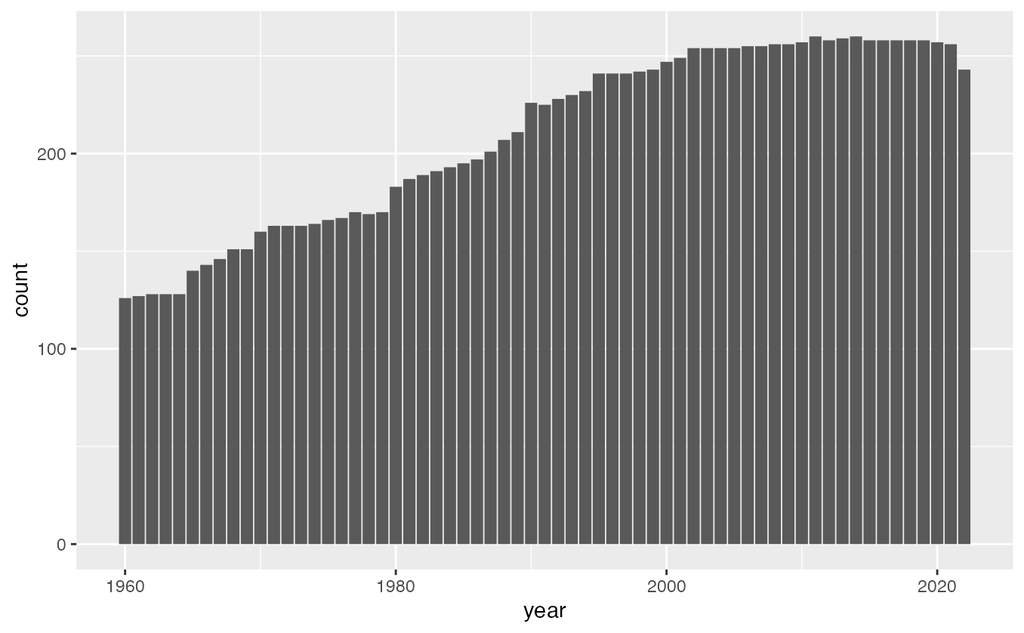

```r
df_yourdata |> drop_na(gdp) |>
  ggplot(aes(year)) + geom_bar()
```

### Creating a long table

#### Example.

```
df_sec_ter_gdp_long <- df_sec_ter_gdp |>
  pivot_longer(cols = c(secondary, tertiary))
df_sec_ter_gdp_long
```

*Generate a long table. The following works fine, but it is also good to change the order of the selected columns needed. The following codes do the same. “name” and “value” are added as default.*

```r
df_yourdata_long <- df_yourdata |> pivot_longer(cols = c(agriculture, industry, service), names_to = "name", values_to = "value")
df_yourdata_long
```

```r
df_yourdata_long <- df_yourdata |>
  pivot_longer(cols = agriculture:service)
df_yourdata_long
```

| country | iso2c | iso3c | year | status | lastupdated | gdp | region | capital | longitude | latitude | income | lending | name | value |
| --- | --- | --- | --- | --- | --- | --- | --- | --- | --- | --- | --- | --- | --- | --- |
| Afghanistan | AF | AFG | 2012 | NA | 2023-12-18 | 1.990733e+10 | South Asia | Kabul | 69.17610 | 34.5228 | Low income | IDA | agriculture | 1214.3155 |
| Afghanistan | AF | AFG | 2012 | NA | 2023-12-18 | 1.990733e+10 | South Asia | Kabul | 69.17610 | 34.5228 | Low income | IDA | industry | 3556.2628 |
| Afghanistan | AF | AFG | 2012 | NA | 2023-12-18 | 1.990733e+10 | South Asia | Kabul | 69.17610 | 34.5228 | Low income | IDA | service | 4015.9177 |
| Afghanistan | AF | AFG | 2008 | NA | 2023-12-18 | 1.010930e+10 | South Asia | Kabul | 69.17610 | 34.5228 | Low income | IDA | agriculture | 811.9071 |
| Afghanistan | AF | AFG | 2008 | NA | 2023-12-18 | 1.010930e+10 | South Asia | Kabul | 69.17610 | 34.5228 | Low income | IDA | industry | 3890.1030 |
| Afghanistan | AF | AFG | 2008 | NA | 2023-12-18 | 1.010930e+10 | South Asia | Kabul | 69.17610 | 34.5228 | Low income | IDA | service | 3056.5457 |
| Afghanistan | AF | AFG | 2009 | NA | 2023-12-18 | 1.241615e+10 | South Asia | Kabul | 69.17610 | 34.5228 | Low income | IDA | agriculture | 1203.5427 |
| Afghanistan | AF | AFG | 2009 | NA | 2023-12-18 | 1.241615e+10 | South Asia | Kabul | 69.17610 | 34.5228 | Low income | IDA | industry | 3718.5792 |
| Afghanistan | AF | AFG | 2009 | NA | 2023-12-18 | 1.241615e+10 | South Asia | Kabul | 69.17610 | 34.5228 | Low income | IDA | service | 3397.7212 |
| Afghanistan | AF | AFG | 2004 | NA | 2023-12-18 | 5.224897e+09 | South Asia | Kabul | 69.17610 | 34.5228 | Low income | IDA | agriculture | 780.2329 |

[output cut: 990 more lines]

*Select columns of a long table and change the order of the variables.*

```r
df_yourdata_long <- df_yourdata |>
  pivot_longer(cols = agriculture:service) |>
  select(country, iso2c, year, gdp, name, value, region, income)
```

*With a long table, you can display the following chart as well. Compare with a similar chart above.*

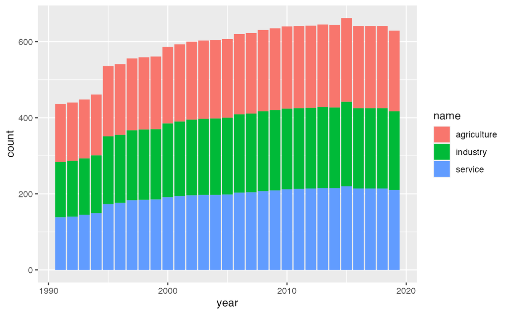

```r
df_yourdata_long |> drop_na(value) |>
  ggplot(aes(year, fill = name)) + geom_bar()
```

### Visualizing data

```r
df_yourdata_long
```

| country | iso2c | year | gdp | name | value | region | income |
| --- | --- | --- | --- | --- | --- | --- | --- |
| Afghanistan | AF | 2012 | 1.990733e+10 | agriculture | 1214.3155 | South Asia | Low income |
| Afghanistan | AF | 2012 | 1.990733e+10 | industry | 3556.2628 | South Asia | Low income |
| Afghanistan | AF | 2012 | 1.990733e+10 | service | 4015.9177 | South Asia | Low income |
| Afghanistan | AF | 2008 | 1.010930e+10 | agriculture | 811.9071 | South Asia | Low income |
| Afghanistan | AF | 2008 | 1.010930e+10 | industry | 3890.1030 | South Asia | Low income |
| Afghanistan | AF | 2008 | 1.010930e+10 | service | 3056.5457 | South Asia | Low income |
| Afghanistan | AF | 2009 | 1.241615e+10 | agriculture | 1203.5427 | South Asia | Low income |
| Afghanistan | AF | 2009 | 1.241615e+10 | industry | 3718.5792 | South Asia | Low income |
| Afghanistan | AF | 2009 | 1.241615e+10 | service | 3397.7212 | South Asia | Low income |
| Afghanistan | AF | 2004 | 5.224897e+09 | agriculture | 780.2329 | South Asia | Low income |

[output cut: 990 more lines]

**Observations and Questions:**

- *It is easier to see the main part of the data.*

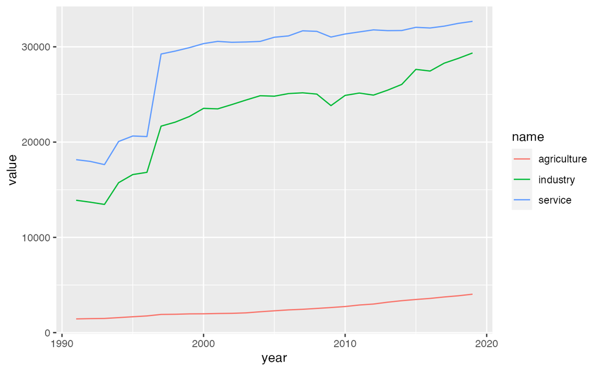

```r
df_yourdata_long |> filter(country == "World") |> drop_na(value) |>
  ggplot(aes(year, value, col = name)) + geom_line()
```

**Observations and Questions:**

- *You can create the line chart above easily using col = name, if you have a long table.*

```r
INCOME <- df_yourdata |> drop_na(income) |>
  filter(income != "Aggregates") |> filter(income != "Not classified") |>
  distinct(income) |> pull()
INCOME
```

```
[1] "Low income"          "Upper middle income" "Lower middle income" "High income"
```

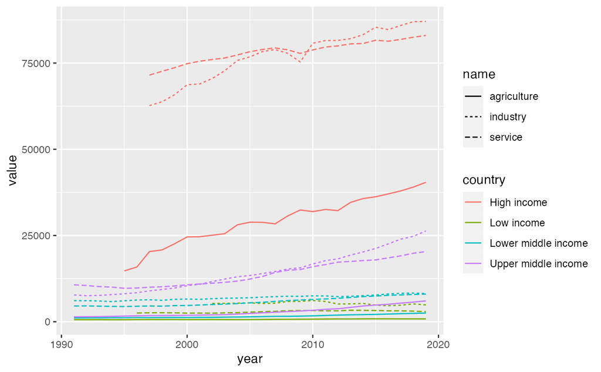

```r
df_yourdata_long |> filter(country %in% INCOME) |> drop_na(value) |>
  ggplot(aes(year, value, col = country, linetype = name)) + geom_line()
```

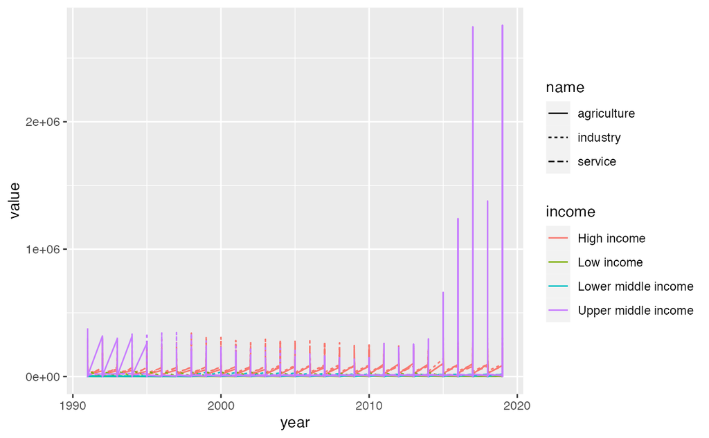

```r
df_yourdata_long |> drop_na(value) |> filter(income %in% INCOME) |>
  ggplot(aes(year, value, col = income, linetype = name)) + geom_line()
```

**Observations and Questions:**

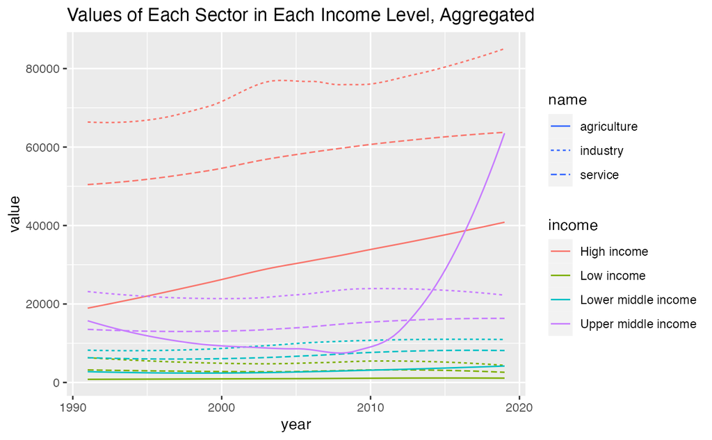

```r
df_yourdata_long |> drop_na(value) |> filter(income %in% INCOME) |>
  ggplot(aes(year, value, col = income, linetype = name)) +
  geom_smooth(formula = 'y ~ x', method = "loess", se=FALSE, linewidth = 0.5) +
  labs(title = "Values of Each Sector in Each Income Level, Aggregated")
```

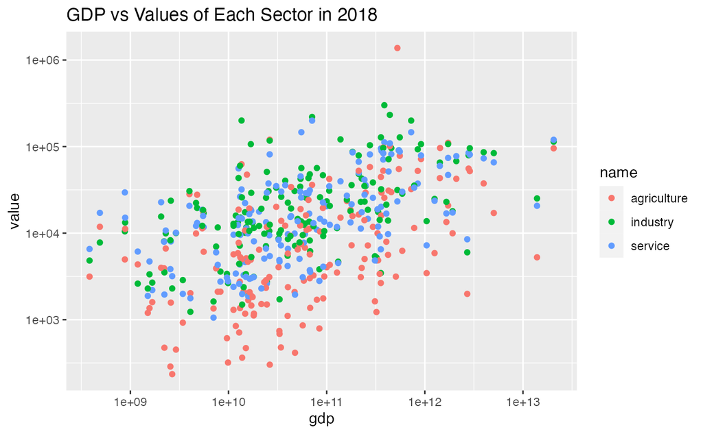

```r
df_yourdata_long |> filter(year == 2018) |> filter(region != "Aggregates") |>
  drop_na(value) |>
  ggplot(aes(gdp, value, col = name)) + geom_point() +
  scale_x_log10() + scale_y_log10() +
  labs(title = "GDP vs Values of Each Sector in 2018")
```

**Observations and Questions:**

- *What happens if we are not using log10 scales.*

### A choropleth map

```r
library(rnaturalearth)
library(rnaturalearthdata)
```

```r
ne_world <- ne_countries(scale = "medium", returnclass = "sf")
```

*A couple of students had an error when they changed “medium” to “large”. I also had the same error when I checked using Windows OS. You can stay with “medium” but if you want to use “large”, please follow the following steps.*

1. *Install `devtools` package, either by running `install.packages("devtools")` or intall it from Install Packages under Tools in the menu.*
2. *Then run the following in Console: `devtools::install_github("ropensci/rnaturalearthhires")`*

If possible, create a choropleth map. (a challenge, not required)

```r
df_yourdata |> filter(year == 2022) |> drop_na(gdp) |> pull(gdp) |>
  quantile(probs = c(0.25,0.5,0.75,1))
```

```
         25%          50%          75%         100%
1.403573e+10 7.573231e+10 8.912561e+11 1.013257e+14
```

```r
df_gdp_2022 <- df_yourdata |> filter(year == 2022) |> select(iso2c, gdp)
ne_gdp_2022 <- ne_world |> left_join(df_gdp_2022, by = c("wb_a2" = "iso2c"))
```

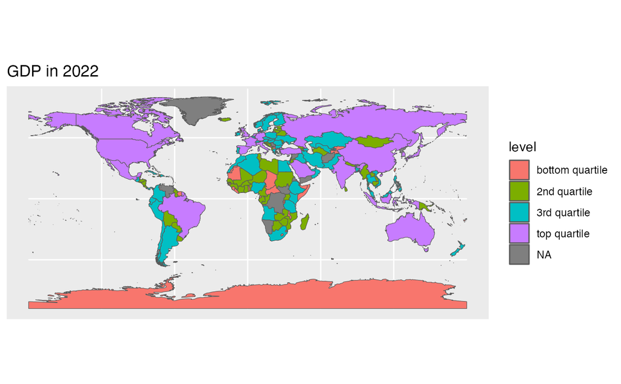

```r
ne_gdp_2022 |> mutate(level = cut(gdp, breaks = c(0, 1.403573e+10, 7.573231e+10, 8.912561e+11, 1.013257e+14), labels = c("bottom quartile","2nd quartile","3rd quartile","top quartile"))) |> ggplot() + geom_sf(aes(fill = level)) + labs(title = "GDP in 2022")
```

```r
df_yourdata |> filter(year == 1960) |> drop_na(gdp) |> pull(gdp) |>
  quantile(probs = c(0.25,0.5,0.75,1))
```

```
         25%          50%          75%         100%
5.151683e+08 2.661058e+09 2.398013e+10 1.381135e+12
```

```r
df_gdp_1960 <- df_yourdata |> filter(year == 1960) |> select(iso2c, gdp)
ne_gdp_1960 <- ne_world |> left_join(df_gdp_1960, by = c("wb_a2" = "iso2c"))
```

[figure not shown]

```r
ne_gdp_2022 |> mutate(level = cut(gdp, breaks = c(0, 5.151683e+08, 2.661058e+09, 2.398013e+10, 1.381135e+12), labels = c("bottom quartile","2nd quartile","3rd quartile","top quartile"))) |> ggplot() + geom_sf(aes(fill = level)) + labs(title = "GDP in 1960")
```

**Observations and Questions:**

- *What can you see?*

*Before you turn in:*

1. *Run all from the top.*
2. *Preview*
3. *View R Notebook file in your web browser.*

*Then post your R Notebook file, i.e., w4_g1234556x.nb.html.*

*If you had a lot of errors and could not generate R Notebook file properly, post both R Notebook file and R Markdown file, i.e., w4_g123456x.Rmd.*